# India Food Prices

Balagopal

October 1, 2017

### Frame

- Which commodity has the highest price?
- To determine the overall price trend - trend of all commodity prices over time
- To predict the price of mustard oil for the next 12 months

### Acquire

Getting the data from ‘Global Food Prices’ database. Since, it contains more than 7 lakh records, filtering the food price data only for India, which comes close to 68K records.

```r
getwd()
```

```
## [1] "C:/Big Data/2nd weekend/SVAP"
```

```r
df <- read.csv("Indian_FoodPrices.csv", header = TRUE)
str(df)
```

```
## 'data.frame':    68308 obs. of  18 variables:
##  $ adm0_id           : int  115 115 115 115 115 115 115 115 115 115 ...
##  $ adm0_name         : Factor w/ 1 level "India": 1 1 1 1 1 1 1 1 1 1 ...
##  $ adm1_id           : int  1509 1509 1509 1509 1509 1509 1509 1509 1509 1509 ...
##  $ adm1_name         : Factor w/ 29 levels "","$Chandigarh",..: 27 27 27 27 27 27 27 27 27 27 ...
##  $ mkt_id            : int  921 921 921 921 921 921 921 921 921 921 ...
##  $ mkt_name          : Factor w/ 61 levels "Agartala","Agra",..: 1 1 1 1 1 1 1 1 1 1 ...
##  $ cm_id             : int  52 52 52 52 52 52 52 52 52 52 ...
##  $ cm_name           : Factor w/ 21 levels "Ghee (vanaspati)",..: 14 14 14 14 14 14 14 14 14 14 ...
##  $ cur_id            : int  68 68 68 68 68 68 68 68 68 68 ...
##  $ cur_name          : Factor w/ 1 level "INR": 1 1 1 1 1 1 1 1 1 1 ...
##  $ pt_id             : int  15 15 15 15 15 15 15 15 15 15 ...
##  $ pt_name           : Factor w/ 1 level "Retail": 1 1 1 1 1 1 1 1 1 1 ...
##  $ um_id             : int  5 5 5 5 5 5 5 5 5 5 ...
##  $ um_name           : Factor w/ 2 levels "KG","L": 1 1 1 1 1 1 1 1 1 1 ...
##  $ mp_month          : int  1 3 4 5 6 7 8 9 10 11 ...
##  $ mp_year           : int  1996 1996 1996 1996 1996 1996 1996 1996 1996 1996 ...
##  $ mp_price          : num  8 8.5 8.75 8.75 8.5 9 9 9 9 9 ...
##  $ mp_commoditysource: Factor w/ 1 level "M/o Consumer Affairs, Food and Public Distribution, Government of India": 1 1 1 1 1 1 1 1 1 1 ...
```

### Refine the data

Do all the necessary cleanup, removing NA values if applicable and changing to meaningful column names

```r
column_name <- c("Country_ID", "Country", "Region_ID", "Region", "Market_ID", "Market", "Commodity_ID", "Commodity", "Currency_ID", "Currency", "Sector_ID", "Sector", "Units_ID", "Units", "Month", "Year", "Price", "Commodity_Source")
colnames(df) <- column_name
str(df)
```

```
## 'data.frame':    68308 obs. of  18 variables:
##  $ Country_ID      : int  115 115 115 115 115 115 115 115 115 115 ...
##  $ Country         : Factor w/ 1 level "India": 1 1 1 1 1 1 1 1 1 1 ...
##  $ Region_ID       : int  1509 1509 1509 1509 1509 1509 1509 1509 1509 1509 ...
##  $ Region          : Factor w/ 29 levels "","$Chandigarh",..: 27 27 27 27 27 27 27 27 27 27 ...
##  $ Market_ID       : int  921 921 921 921 921 921 921 921 921 921 ...
##  $ Market          : Factor w/ 61 levels "Agartala","Agra",..: 1 1 1 1 1 1 1 1 1 1 ...
##  $ Commodity_ID    : int  52 52 52 52 52 52 52 52 52 52 ...
##  $ Commodity       : Factor w/ 21 levels "Ghee (vanaspati)",..: 14 14 14 14 14 14 14 14 14 14 ...
##  $ Currency_ID     : int  68 68 68 68 68 68 68 68 68 68 ...
##  $ Currency        : Factor w/ 1 level "INR": 1 1 1 1 1 1 1 1 1 1 ...
##  $ Sector_ID       : int  15 15 15 15 15 15 15 15 15 15 ...
##  $ Sector          : Factor w/ 1 level "Retail": 1 1 1 1 1 1 1 1 1 1 ...
##  $ Units_ID        : int  5 5 5 5 5 5 5 5 5 5 ...
##  $ Units           : Factor w/ 2 levels "KG","L": 1 1 1 1 1 1 1 1 1 1 ...
##  $ Month           : int  1 3 4 5 6 7 8 9 10 11 ...
##  $ Year            : int  1996 1996 1996 1996 1996 1996 1996 1996 1996 1996 ...
##  $ Price           : num  8 8.5 8.75 8.75 8.5 9 9 9 9 9 ...
##  $ Commodity_Source: Factor w/ 1 level "M/o Consumer Affairs, Food and Public Distribution, Government of India": 1 1 1 1 1 1 1 1 1 1 ...
```

```r
unique(df$Commodity)
```

```
##  [1] Rice                Wheat flour         Lentils (masur)
##  [4] Potatoes            Sugar               Lentils
##  [7] Tomatoes            Onions              Tea (black)
## [10] Oil (mustard)       Oil (soybean)       Lentils (moong)
## [13] Sugar (jaggery/gur) Lentils (urad)      Ghee (vanaspati)
## [16] Salt (iodised)      Milk (pasteurized)  Oil (palm)
## [19] Wheat               Oil (sunflower)     Oil (groundnut)
## 21 Levels: Ghee (vanaspati) Lentils Lentils (masur) ... Wheat flour
```

```r
df[is.na(df$Commodity), ]
```

```
##  [1] Country_ID       Country          Region_ID        Region
##  [5] Market_ID        Market           Commodity_ID     Commodity
##  [9] Currency_ID      Currency         Sector_ID        Sector
## [13] Units_ID         Units            Month            Year
## [17] Price            Commodity_Source
## <0 rows> (or 0-length row.names)
```

```r
df$Commodity <- gsub(" ", "", df$Commodity)
df$Commodity <- gsub("Lentils\\(masur\\)", "Masoor_dal", df$Commodity)
df$Commodity <- gsub("\\(black\\)", "", df$Commodity)
df$Commodity <- gsub("Oil\\(mustard\\)", "Mustard_oil", df$Commodity)
df$Commodity <- gsub("Oil\\(soybean\\)", "Soybean_oil", df$Commodity)
df$Commodity <- gsub("Lentils\\(moong\\)", "Moong_dal", df$Commodity)
df$Commodity <- gsub("Sugar\\(jaggery\\/gur\\)", "Jaggery", df$Commodity)
df$Commodity <- gsub("Lentils\\(urad\\)", "Urad_dal", df$Commodity)
df$Commodity <- gsub("\\(vanaspati\\)", "", df$Commodity)
df$Commodity <- gsub("\\(iodised\\)", "", df$Commodity)
df$Commodity <- gsub("\\(pasteurized\\)", "", df$Commodity)
df$Commodity <- gsub("Oil\\(palm\\)", "Palm_oil", df$Commodity)
df$Commodity <- gsub("Oil\\(sunflower\\)", "Sunflower_oil", df$Commodity)
df$Commodity <- gsub("Oil\\(groundnut\\)", "Groundnut_oil", df$Commodity)
df[is.na(df$Price), ]
```

```
##  [1] Country_ID       Country          Region_ID        Region
##  [5] Market_ID        Market           Commodity_ID     Commodity
##  [9] Currency_ID      Currency         Sector_ID        Sector
## [13] Units_ID         Units            Month            Year
## [17] Price            Commodity_Source
## <0 rows> (or 0-length row.names)
```

```r
df[df$Price == 0.00, ]
```

```
##  [1] Country_ID       Country          Region_ID        Region
##  [5] Market_ID        Market           Commodity_ID     Commodity
##  [9] Currency_ID      Currency         Sector_ID        Sector
## [13] Units_ID         Units            Month            Year
## [17] Price            Commodity_Source
## <0 rows> (or 0-length row.names)
```

```r
df[is.na(df$Year), ]
```

```
##  [1] Country_ID       Country          Region_ID        Region
##  [5] Market_ID        Market           Commodity_ID     Commodity
##  [9] Currency_ID      Currency         Sector_ID        Sector
## [13] Units_ID         Units            Month            Year
## [17] Price            Commodity_Source
## <0 rows> (or 0-length row.names)
```

```r
df[is.na(df$Month), ]
```

```
##  [1] Country_ID       Country          Region_ID        Region
##  [5] Market_ID        Market           Commodity_ID     Commodity
##  [9] Currency_ID      Currency         Sector_ID        Sector
## [13] Units_ID         Units            Month            Year
## [17] Price            Commodity_Source
## <0 rows> (or 0-length row.names)
```

```r
df[df$Year == 0, ]
```

```
##  [1] Country_ID       Country          Region_ID        Region
##  [5] Market_ID        Market           Commodity_ID     Commodity
##  [9] Currency_ID      Currency         Sector_ID        Sector
## [13] Units_ID         Units            Month            Year
## [17] Price            Commodity_Source
## <0 rows> (or 0-length row.names)
```

```r
df[df$Month == 0, ]
```

```
##  [1] Country_ID       Country          Region_ID        Region
##  [5] Market_ID        Market           Commodity_ID     Commodity
##  [9] Currency_ID      Currency         Sector_ID        Sector
## [13] Units_ID         Units            Month            Year
## [17] Price            Commodity_Source
## <0 rows> (or 0-length row.names)
```

### Transform, Explore and Model

To plot a line graph of price trend of all commodities over time.

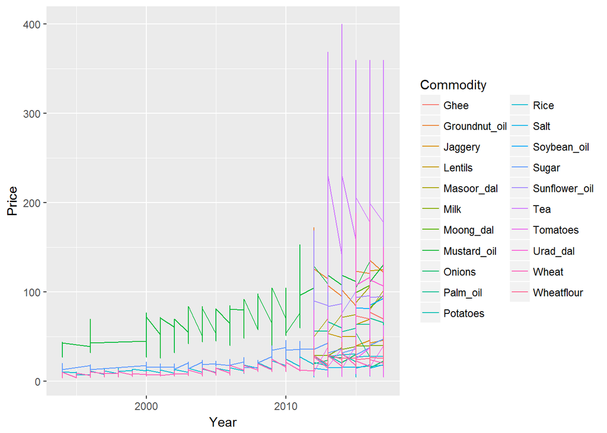

```r
library(ggplot2)
library(dplyr)
ggplot(df, aes(x=df$Year, y=df$Price)) + geom_line(aes(color=df$Commodity)) + xlab("Year") + ylab("Price") + scale_color_discrete(name="Commodity")
```

Conclusion: This clearly shows that, there is a general increase in price trend of all commodities, but it is not clearly distinguishable in this type of graph. Also, there is a large variance in a price of a particular commodity in a particular year.

To make it more clear, we are plotting a point graph.

```
## 'colour', which will replace the existing scale.
```

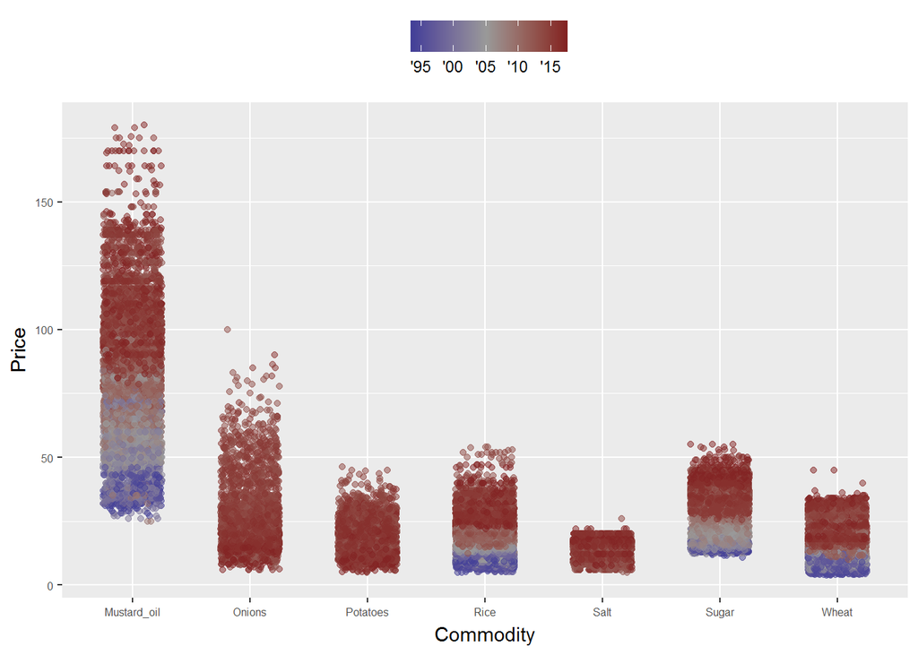

```r
library(scales)
df1 <- subset(df, df$Commodity %in% c("Mustard_oil", "Onions", "Potatoes", "Rice", "Salt", "Sugar", "Wheat"))
ggplot(df1, aes(x = df1$Commodity, y = df1$Price)) + theme(legend.position="top", axis.text=element_text(size = 6)) + geom_point(aes(color=df1$Year), alpha = 0.5, size = 1.5, position = position_jitter(width = 0.25, height = 0)) + scale_x_discrete(name="Commodity") + scale_color_continuous(name="", breaks=c(1995,2000,2005,2010,2015), labels=c("'95", "'00", "'05", "'10", "'15")) + scale_color_gradient2(name="",breaks=c(1995,2000,2005,2010,2015), labels=c("'95", "'00", "'05", "'10", "'15"), low = muted("blue"), high = muted("red"), mid="gray60", midpoint = 2005 ) + ylab("Price")
```

Conclusion: This clearly shows that, Mustard oil has the highest price among these 7 commodities. Also there is a clear indication of increase in price of the commodities over time. There is some indication that, prices of onions and potatoes has some what reduced as the darker and denser areas are not at the top.

```
## 'colour', which will replace the existing scale.
```

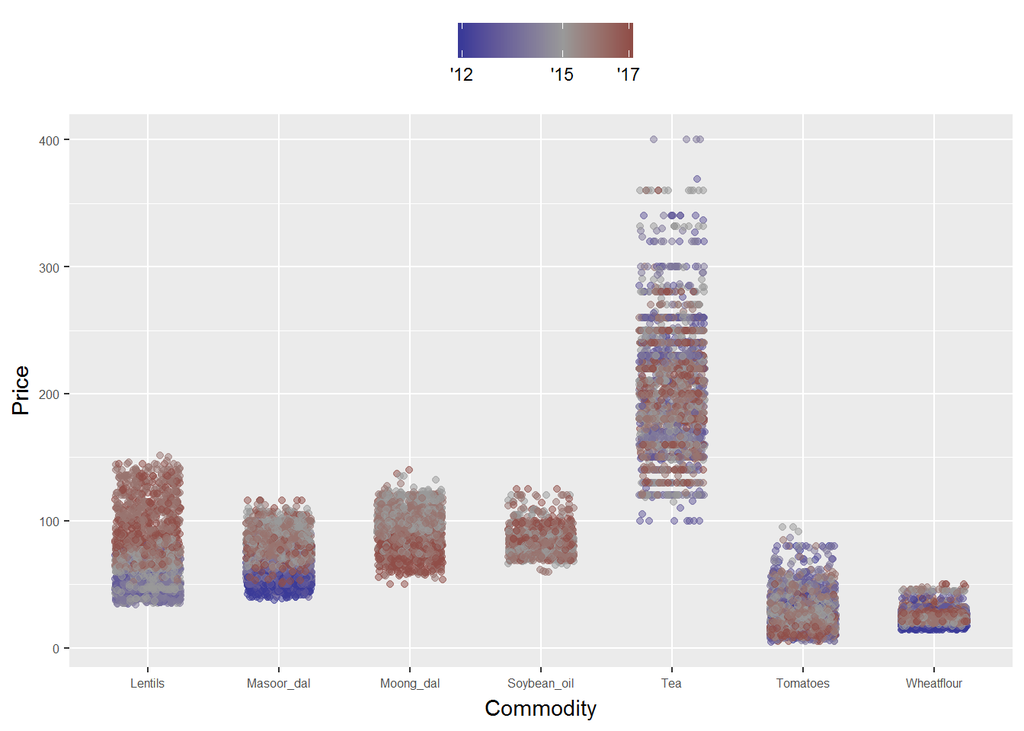

```r
df2 <- subset(df, df$Commodity %in% c("Wheatflour", "Masoor_dal", "Lentils", "Tomatoes", "Tea", "Soybean_oil", "Moong_dal"))
ggplot(df2, aes(x = df2$Commodity, y = df2$Price)) + theme(legend.position="top", axis.text=element_text(size = 6)) + geom_point(aes(color=df2$Year), alpha = 0.5, size = 1.5, position = position_jitter(width = 0.25, height = 0)) + scale_x_discrete(name="Commodity") + scale_color_continuous(name="", breaks=c(2012,2015,2017), labels=c("'12", "'15", "'17")) + scale_color_gradient2(name="",breaks=c(2012,2015,2017), labels=c("'12", "'15", "'17"), low = muted("blue"), high = muted("red"), mid="gray60", midpoint = 2015 ) + ylab("Price")
```

Conclusion: This clearly shows that, Tea has the highest price among these 7 commodities. Also there is a clear indication of increase in price of certain commodities like Lentils over time. There is some indication that, prices of Moongdal, Tomatoes, Wheatflour and Tea has some what reduced as the red areas are not at the top.

```
## 'colour', which will replace the existing scale.
```

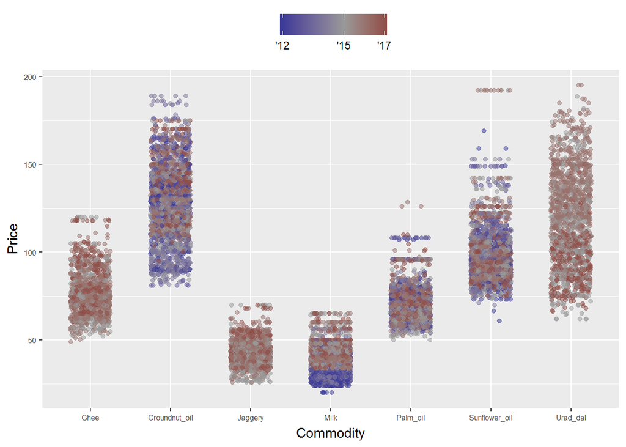

```r
df3 <- subset(df, df$Commodity %in% c("Jaggery", "Urad_dal", "Ghee", "Milk", "Palm_oil", "Sunflower_oil", "Groundnut_oil"))
ggplot(df3, aes(x = df3$Commodity, y = df3$Price)) + theme(legend.position="top", axis.text=element_text(size = 6)) + geom_point(aes(color=df3$Year), alpha = 0.5, size = 1.5, position = position_jitter(width = 0.25, height = 0)) + scale_x_discrete(name="Commodity") + scale_color_continuous(name="", breaks=c(2012,2015,2017), labels=c("'12", "'15", "'17")) + scale_color_gradient2(name="",breaks=c(2012,2015,2017), labels=c("'12", "'15", "'17"), low = muted("blue"), high = muted("red"), mid="gray60", midpoint = 2015 ) + ylab("Price")
```

# Commodity price relative to max in period

```r
overallPriceTrend <- df %>% group_by(Commodity, Year) %>% summarise(globalAveragePrice = mean(Price) / max(Price))
str(overallPriceTrend)
```

```
## Classes 'grouped_df', 'tbl_df', 'tbl' and 'data.frame':  173 obs. of  3 variables:
##  $ Commodity         : chr  "Ghee" "Ghee" "Ghee" "Groundnut_oil" ...
##  $ Year              : int  2015 2016 2017 2012 2013 2014 2015 2016 2017 2015 ...
##  $ globalAveragePrice: num  0.624 0.634 0.677 0.741 0.692 ...
##  - attr(*, "vars")= chr "Commodity"
##  - attr(*, "drop")= logi TRUE
```

```r
# we are selecing a smaller sample for plotting commodities
commodities <- c("Mustard_oil", "Potatoes", "Rice", "Salt", "Sugar", "Wheat", "Onions")
priceTrend <- df %>% select(Price, Commodity, Year) %>% filter(Commodity %in% commodities) %>% group_by(Commodity, Year) %>% summarise(globalAveragePrice = mean(Price) / max(Price))
str(priceTrend)
```

```
## Classes 'grouped_df', 'tbl_df', 'tbl' and 'data.frame':  106 obs. of  3 variables:
##  $ Commodity         : chr  "Mustard_oil" "Mustard_oil" "Mustard_oil" "Mustard_oil" ...
##  $ Year              : int  1994 1996 2000 2001 2002 2003 2004 2005 2006 2007 ...
##  $ globalAveragePrice: num  0.813 0.566 0.555 0.602 0.68 ...
##  - attr(*, "vars")= chr "Commodity"
##  - attr(*, "drop")= logi TRUE
```

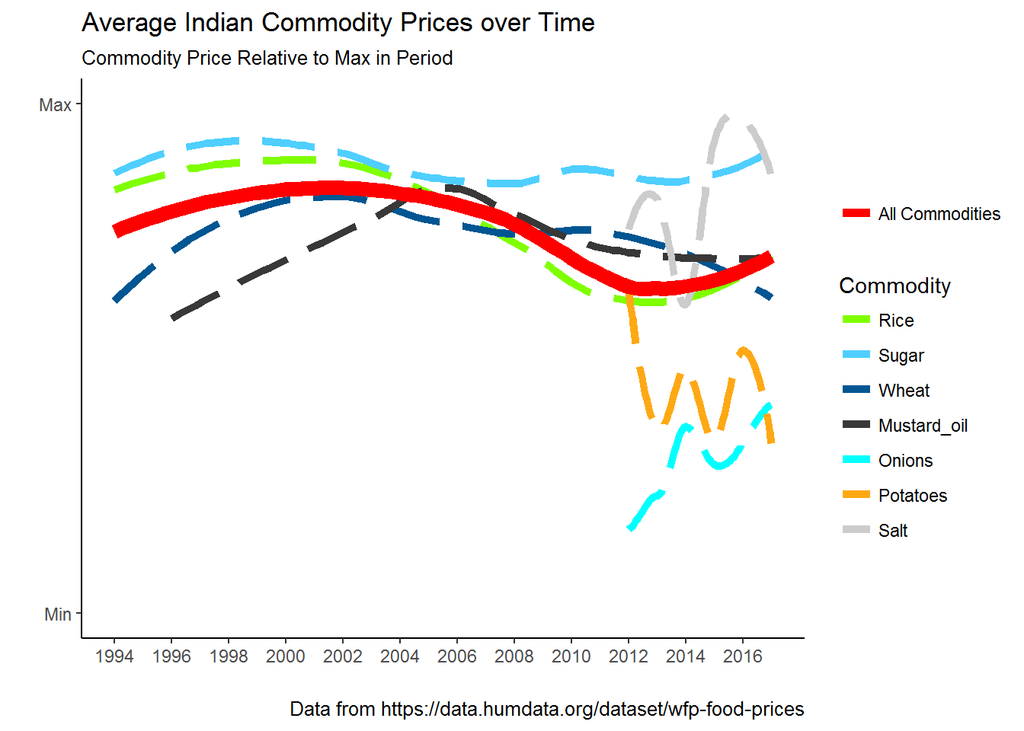

```r
# we will now plot a graph
library(forcats)
colournames <- c("Mustard_oil" = "#383838", "Potatoes" = "#fea814", "Rice" = "#7fff00", "Salt" = "#cccccc", "Sugar" = "#4fcfff", "Wheat" = "#005692", "Onions" = "#00ffff")
# Specify commodity levels for use in our legend
fctLevels <- c("Rice", "Sugar", "Wheat", "Mustard_oil", "Onions", "Potatoes", "Salt")
ggplot(priceTrend, aes(x = Year, y = globalAveragePrice)) +
  geom_smooth(aes(colour = fct_relevel(Commodity, fctLevels)), se = FALSE, size = 1.8, linetype = 5) +
  geom_smooth(data = overallPriceTrend, colour = "red", se = FALSE, size = 3.5) +
  geom_line(aes(size = "All Commodities", linetype = NA), colour = "red") +
  scale_colour_manual(values = colournames) +
  scale_x_continuous(breaks = seq(1994, 2017, 2)) +
  scale_y_continuous(limits = c(0.2, 0.8), labels = c("Min", "Max"), breaks = c(0.2, 0.8)) +
  labs(title = "Average Indian Commodity Prices over Time",
       subtitle = "Commodity Price Relative to Max in Period",
       caption = "Data from https://data.humdata.org/dataset/wfp-food-prices",
       x = "",
       y = "",
       colour = "Commodity",
       size = "") +
  theme_classic()
```

# To predict the price of mustard oil in the next 12 months

```r
library(tidyr)
dfpredict <- df %>% unite(Date, Year, Month, sep="-")
str(dfpredict)
```

```
## 'data.frame':    68308 obs. of  17 variables:
##  $ Country_ID      : int  115 115 115 115 115 115 115 115 115 115 ...
##  $ Country         : Factor w/ 1 level "India": 1 1 1 1 1 1 1 1 1 1 ...
##  $ Region_ID       : int  1509 1509 1509 1509 1509 1509 1509 1509 1509 1509 ...
##  $ Region          : Factor w/ 29 levels "","$Chandigarh",..: 27 27 27 27 27 27 27 27 27 27 ...
##  $ Market_ID       : int  921 921 921 921 921 921 921 921 921 921 ...
##  $ Market          : Factor w/ 61 levels "Agartala","Agra",..: 1 1 1 1 1 1 1 1 1 1 ...
##  $ Commodity_ID    : int  52 52 52 52 52 52 52 52 52 52 ...
##  $ Commodity       : chr  "Rice" "Rice" "Rice" "Rice" ...
##  $ Currency_ID     : int  68 68 68 68 68 68 68 68 68 68 ...
##  $ Currency        : Factor w/ 1 level "INR": 1 1 1 1 1 1 1 1 1 1 ...
##  $ Sector_ID       : int  15 15 15 15 15 15 15 15 15 15 ...
##  $ Sector          : Factor w/ 1 level "Retail": 1 1 1 1 1 1 1 1 1 1 ...
##  $ Units_ID        : int  5 5 5 5 5 5 5 5 5 5 ...
##  $ Units           : Factor w/ 2 levels "KG","L": 1 1 1 1 1 1 1 1 1 1 ...
##  $ Date            : chr  "1996-1" "1996-3" "1996-4" "1996-5" ...
##  $ Price           : num  8 8.5 8.75 8.75 8.5 9 9 9 9 9 ...
##  $ Commodity_Source: Factor w/ 1 level "M/o Consumer Affairs, Food and Public Distribution, Government of India": 1 1 1 1 1 1 1 1 1 1 ...
```

```r
dfpredict$Date <- as.Date(paste(dfpredict$Date, "-01", sep = ""), "%Y-%m-%d")
str(dfpredict)
```

```
## 'data.frame':    68308 obs. of  17 variables:
##  $ Country_ID      : int  115 115 115 115 115 115 115 115 115 115 ...
##  $ Country         : Factor w/ 1 level "India": 1 1 1 1 1 1 1 1 1 1 ...
##  $ Region_ID       : int  1509 1509 1509 1509 1509 1509 1509 1509 1509 1509 ...
##  $ Region          : Factor w/ 29 levels "","$Chandigarh",..: 27 27 27 27 27 27 27 27 27 27 ...
##  $ Market_ID       : int  921 921 921 921 921 921 921 921 921 921 ...
##  $ Market          : Factor w/ 61 levels "Agartala","Agra",..: 1 1 1 1 1 1 1 1 1 1 ...
##  $ Commodity_ID    : int  52 52 52 52 52 52 52 52 52 52 ...
##  $ Commodity       : chr  "Rice" "Rice" "Rice" "Rice" ...
##  $ Currency_ID     : int  68 68 68 68 68 68 68 68 68 68 ...
##  $ Currency        : Factor w/ 1 level "INR": 1 1 1 1 1 1 1 1 1 1 ...
##  $ Sector_ID       : int  15 15 15 15 15 15 15 15 15 15 ...
##  $ Sector          : Factor w/ 1 level "Retail": 1 1 1 1 1 1 1 1 1 1 ...
##  $ Units_ID        : int  5 5 5 5 5 5 5 5 5 5 ...
##  $ Units           : Factor w/ 2 levels "KG","L": 1 1 1 1 1 1 1 1 1 1 ...
##  $ Date            : Date, format: "1996-01-01" "1996-03-01" ...
##  $ Price           : num  8 8.5 8.75 8.75 8.5 9 9 9 9 9 ...
##  $ Commodity_Source: Factor w/ 1 level "M/o Consumer Affairs, Food and Public Distribution, Government of India": 1 1 1 1 1 1 1 1 1 1 ...
```

```r
dfmustard <- dfpredict %>% filter(Commodity==c("Mustard_oil")) %>% select(Date, Price)
dfmustard1 <- dfmustard %>% group_by(Date) %>% summarise(Price1=mean(Price))
colnames(dfmustard1) <- c('ds', 'y')
library(prophet)
m <- prophet(dfmustard1)
```

```
## Initial log joint probability = -3.04765
## Optimization terminated normally:
##   Convergence detected: relative gradient magnitude is below tolerance
```

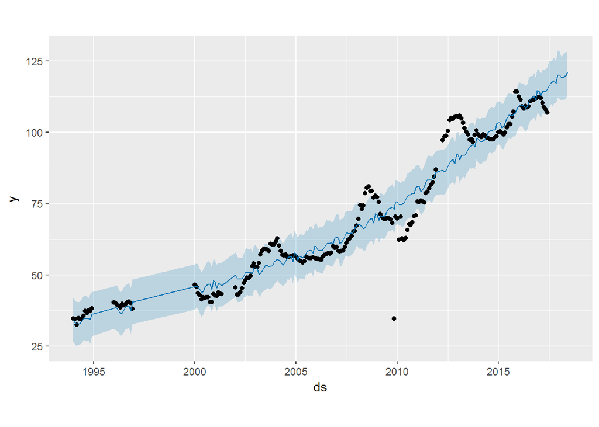

```r
future <- make_future_dataframe(m, period=12, freq="m")
forecast <- predict(m, future)
plot(m, forecast)
```

Conclusion: This clearly shows that, the price of Mustard oil is increasing in the next 12 months. But the variablility of the price for a particular date is more across all the markets of India.